# F1 2017 Italy, Qualifying

Drivers progressed through the qualifying session as follows:

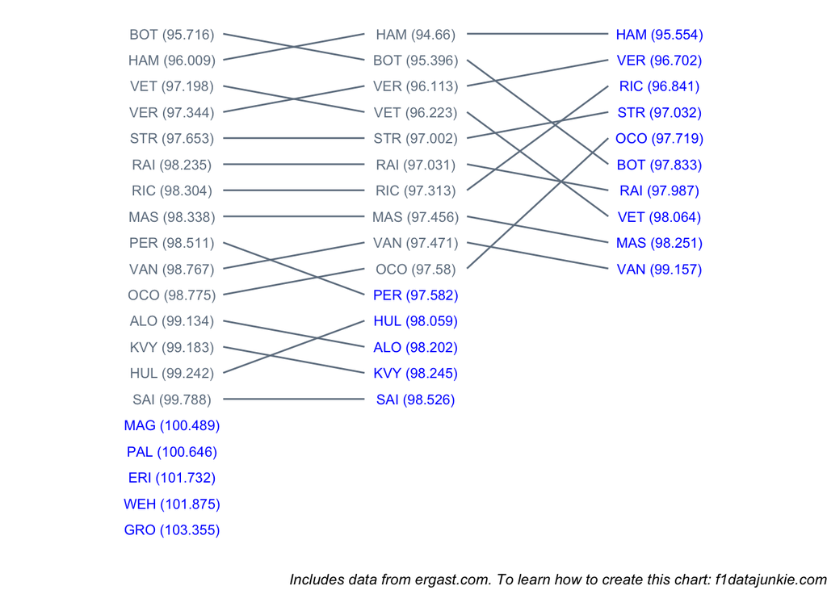

Going from Q1 to Q2:

- all drivers improved on their best laptime from the previous session

Going from Q2 to Q3:

- HAM failed to improve his time, recording 95.554 compared to 94.66 (0.894s slower)
- VER failed to improve his time, recording 96.702 compared to 96.113 (0.589s slower)
- STR failed to improve his time, recording 97.032 compared to 97.002 (0.03s slower)
- OCO failed to improve his time, recording 97.719 compared to 97.58 (0.139s slower)
- BOT failed to improve his time, recording 97.833 compared to 95.396 (2.437s slower)
- RAI failed to improve his time, recording 97.987 compared to 97.031 (0.956s slower)
- VET failed to improve his time, recording 98.064 compared to 96.223 (1.841s slower)
- MAS failed to improve his time, recording 98.251 compared to 97.456 (0.795s slower)
- VAN failed to improve his time, recording 99.157 compared to 97.471 (1.686s slower)

Order change going from Q2 to Q3, along with laptime improvement (-ve is a better time in Q3)

```
##    driverName   imp1 driverName  imp2
## 1         VER  0.589        BOT 2.437
## 2         RIC -0.472        STR 0.030
## 3         RIC -0.472        BOT 2.437
## 4         RIC -0.472        RAI 0.956
## 5         RIC -0.472        VET 1.841
## 6         STR  0.030        BOT 2.437
## 7         STR  0.030        VET 1.841
## 8         OCO  0.139        BOT 2.437
## 9         OCO  0.139        RAI 0.956
## 10        OCO  0.139        VET 1.841
## 11        OCO  0.139        MAS 0.795
## 12        OCO  0.139        VAN 1.686
## 13        RAI  0.956        VET 1.841
```

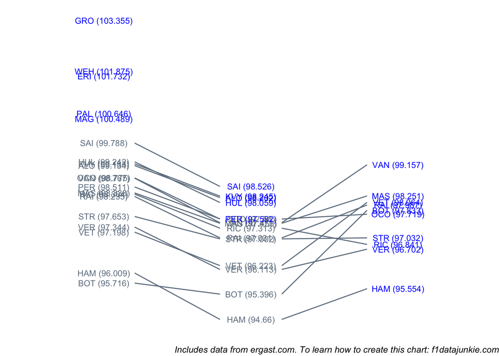

The official session results were recorded as follows:

| POS | DRIVER | Q1 | Q2 | Q3 |
| --- | --- | --- | --- | --- |
| 1 | HAM | 1:36.009 (2) | 1:34.660 (1) | 1:35.554 (1) |
| 2 | VER | 1:37.344 (4) | 1:36.113 (3) | 1:36.702 (2) |
| 3 | RIC | 1:38.304 (7) | 1:37.313 (7) | 1:36.841 (3) |
| 4 | STR | 1:37.653 (5) | 1:37.002 (5) | 1:37.032 (4) |
| 5 | OCO | 1:38.775 (11) | 1:37.580 (10) | 1:37.719 (5) |
| 6 | BOT | 1:35.716 (1) | 1:35.396 (2) | 1:37.833 (6) |
| 7 | RAI | 1:38.235 (6) | 1:37.031 (6) | 1:37.987 (7) |
| 8 | VET | 1:37.198 (3) | 1:36.223 (4) | 1:38.064 (8) |
| 9 | MAS | 1:38.338 (8) | 1:37.456 (8) | 1:38.251 (9) |
| 10 | VAN | 1:38.767 (10) | 1:37.471 (9) | 1:39.157 (10) |
| 11 | PER | 1:38.511 (9) | 1:37.582 (11) |  |
| 12 | HUL | 1:39.242 (14) | 1:38.059 (12) |  |
| 13 | ALO | 1:39.134 (12) | 1:38.202 (13) |  |
| 14 | KVY | 1:39.183 (13) | 1:38.245 (14) |  |
| 15 | SAI | 1:39.788 (15) | 1:38.526 (15) |  |
| 16 | MAG | 1:40.489 (16) |  |  |
| 17 | PAL | 1:40.646 (17) |  |  |
| 18 | ERI | 1:41.732 (18) |  |  |
| 19 | WEH | 1:41.875 (19) |  |  |
| 20 | GRO | 1:43.355 (20) |  |  |

## Session Utilisation

Activity throughout the three qualification sessions took place as follows:

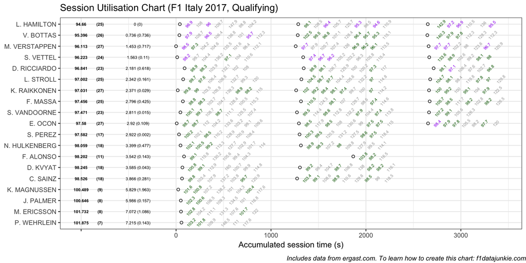

## Q1

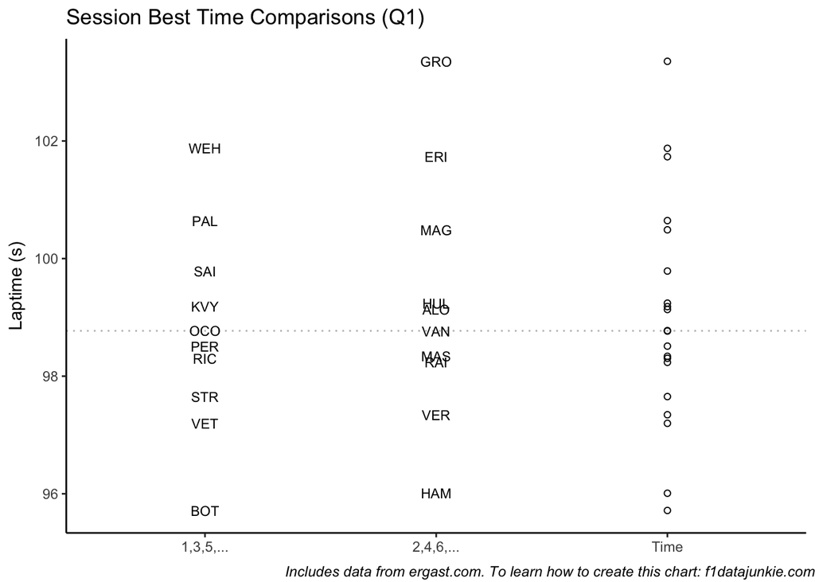

### Cut-off Time Evolution

The cut-off time in Q1 evolved as follows:

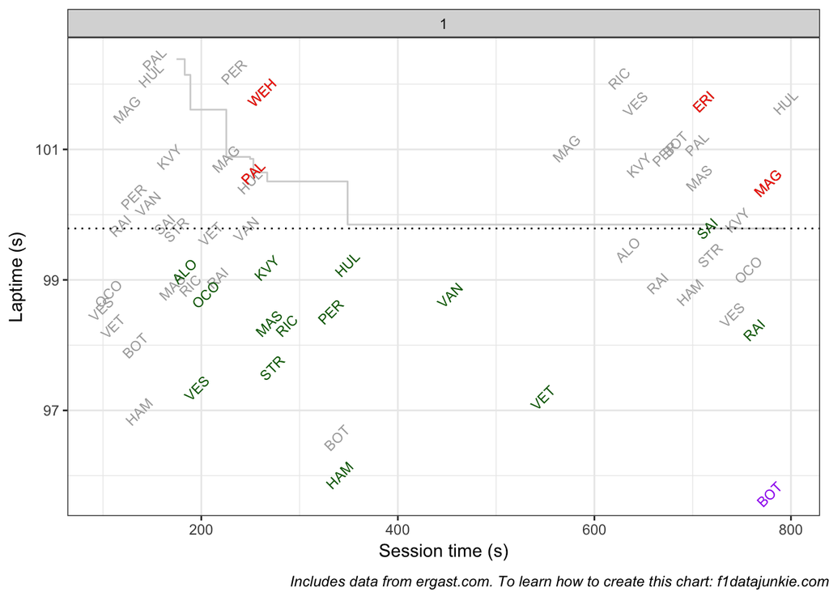

## Q2

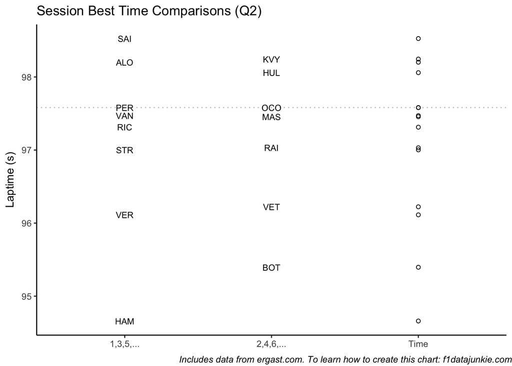

### Cut-off Time Evolution

The cut-off time in Q2 evolved as follows:

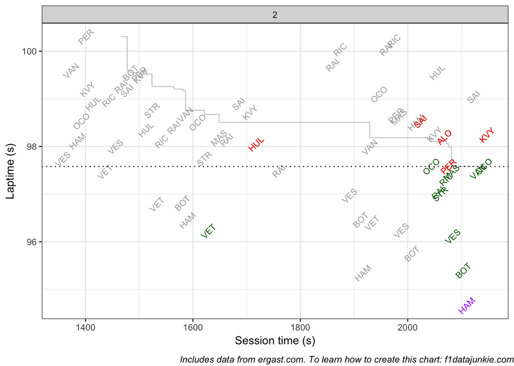

## Q3

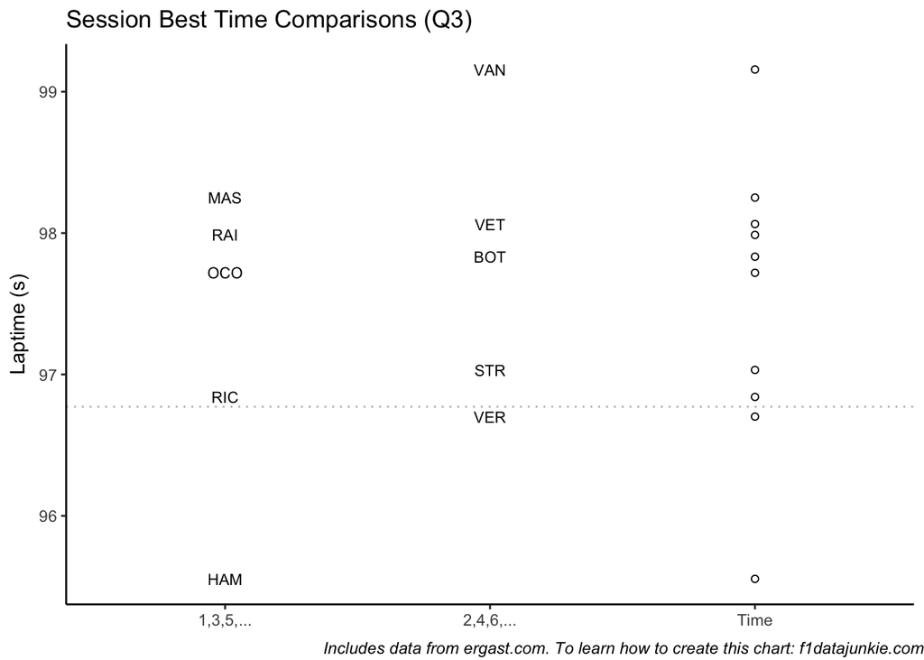

### Front Row Cut-off Time Evolution

The cut-off time in Q3 evolved as follows:

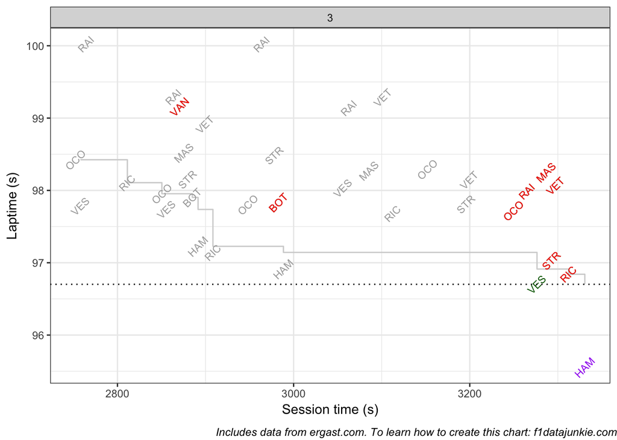

To learn how to wrangle F1 results and timing data to create charts like these, see f1datajunkie.com or [buy the *Wrangling F1 Data With R* book](https://leanpub.com/wranglingf1datawithr).